# ME613 - Análise de Regressão

## Gráficos de Regressão Parcial

## Introdução

Vimos anteriormente:

- Gráfico dos resíduos versus variável preditora: podemos usar para checar presença de curvatura.
- Gráfico dos resíduos versus variável preditora não inclusa no modelo: decidir se deve ser incluída.

Problema: estes gráficos não mostram o efeito marginal de uma variável, dado que as demais já estão no modelo.

## Gráfico de regressão parcial

*Added-variable plots* ou *adjusted variable plots* fornecem informação sobre a importância marginal de \(X_k\), considerando as demais variáveis já incluídas no modelo.

Para o efeito marginal de \(X_k\), consideramos os resíduos da regressão de \(Y\) nas demais variáveis e os resíduos da regressão de \(X_k\) nas demais variáveis.

O gráfico destes dois resíduos mostra a importância marginal de \(X_k\) na redução da variabilidade do resíduo. E também pode fornecer informação sobre a natureza da relação marginal de \(X_k\) com \(Y\).

## Exemplo

Considere uma regressão múltipla de primeira ordem com duas variáveis preditoras: \(X_1\) e \(X_2\).

Queremos estudar o efeito de \(X_1\), dado que \(X_2\) já está no modelo.

- Fazemos a regressão \(Y\) em \(X_2\) e obtemos os resíduos: \(e(Y\mid X_2)\).
- Fazemos a regressão de \(X_1\) em \(X_2\) e obtemos os resíduos: \(e(X_1\mid X_2)\).
- Fazemos o gráfico de \(e(Y\mid X_2)\) versus \(e(X_1\mid X_2)\).

## Exemplo

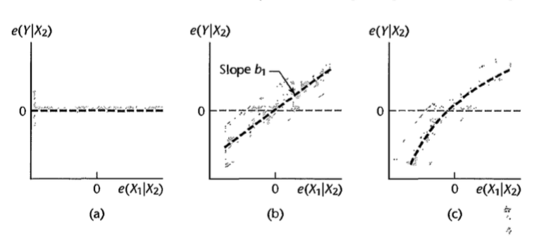

## Exemplo: Salário de gerentes

Para cada gerente: média salarial anual nos últimos 2 anos (\(X_1\)), medida de aversão a risco (\(X_2\)) e valor do seguro de vida (\(Y\)).

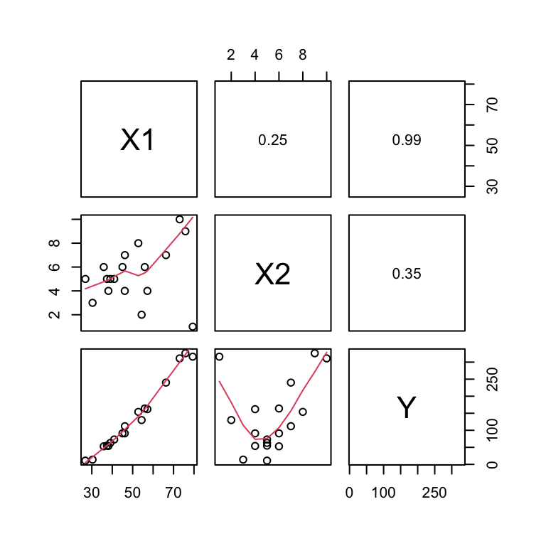

## Exemplo: Salário de gerentes

|  | Estimativa | Erro-Padrão | t | valor de p |
| --- | --- | --- | --- | --- |
| (Intercept) | -205.718659 | 11.3926829 | -18.057086 | 0.0000000 |
| X1 | 6.288029 | 0.2041495 | 30.801102 | 0.0000000 |
| X2 | 4.737602 | 1.3780794 | 3.437829 | 0.0036622 |

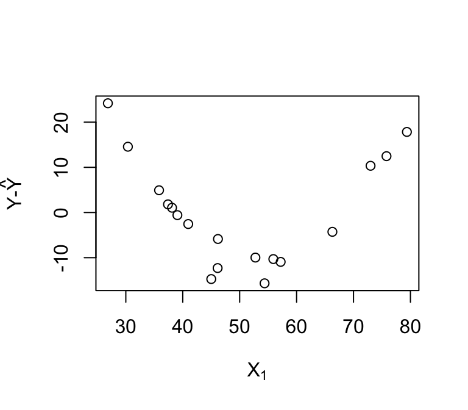

## Exemplo: Salário de gerentes

```r
modelo1 <- lm(Y ~ X2, data=dados)
y_x2 <- resid(modelo1)
modelo2 <- lm(X1 ~ X2, data=dados)
x1_x2 <- resid(modelo2)
modelo3r <- lm(y_x2 ~ x1_x2)
```

|  | Estimativa | Erro-Padrão | t | valor de p |
| --- | --- | --- | --- | --- |
| x1_x2 | 6.288029 | 0.1976669 | 31.81124 | 0 |

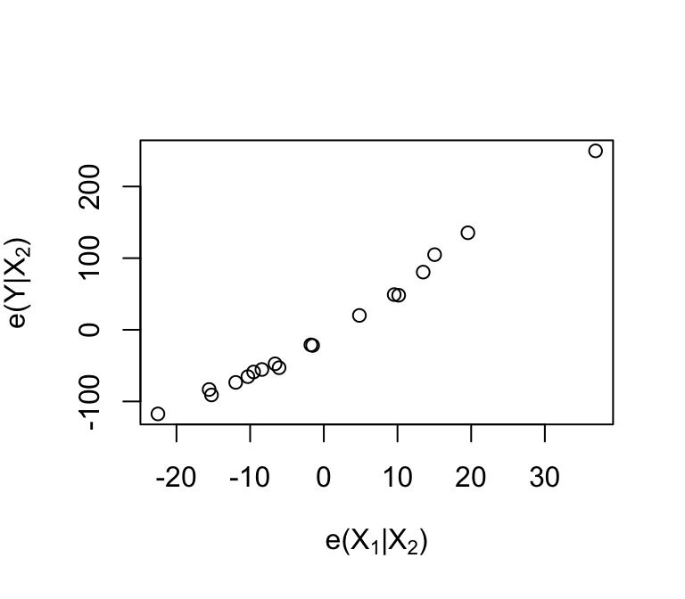

## *Outliers*

## Introdução

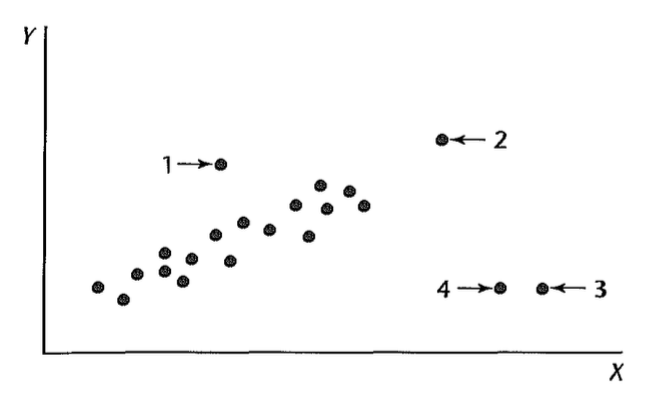

## *Outliers* em \(Y\)

## Resíduo Semi-studentizado

\[e_i^*=\frac{Y_i-\hat{Y}_i}{\sqrt{QME}}\]

Para \(n\) grande, quando \(|e_i^*|>4\) considera-se a \(i\)-ésima observação como *outlier*.

## Exemplo - Gordura corporal

```r
dat = read.table('./dados/fat.txt')
colnames(dat) <- c("X1","X2","X3","Y")
X1 = dat[,1]
X2 = dat[,2]
X3 = dat[,3]
Y = dat[,4]
modelo1 <- lm(Y ~ X1 + X2,data=dat)
rstandard(modelo1)
```

```
##             1             2             3             4             5
## -0.7402261049  1.4765806027 -1.5757913418 -1.3171518783 -0.0001308889
##             6             7             8             9            10
## -0.1519867578  0.3064529233  1.6606069555  1.1095479783 -1.0316491806
##            11            12            13            14            15
##  0.1407848595  0.9272163634 -1.7121512617  1.4686083237  0.2747599004
##            16            17            18            19            20
##  0.2655244112 -0.3538020409 -0.3435016352 -1.1631291289  0.4197625143
```

## Matriz “chapéu”

\[\mathbf{H}_{n\times n} = \mathbf{X}(\mathbf{X}^T\mathbf{X})^{-1}\mathbf{X}^T\]

\[\hat{\mathbf{Y}}=\mathbf{H}\mathbf{Y}\]

\[\mathbf{e}=(\mathbf{I}-\mathbf{H})\mathbf{Y}\]

\[Var(\mathbf{e})=\sigma^2(\mathbf{I}-\mathbf{H})\]

\[Var(e_i)=\sigma^2(1-h_{ii})\]

\[h_{ii}=\mathbf{X}_i^T(\mathbf{X}^T\mathbf{X})^{-1}\mathbf{X}_i\]

\[\mathbf{X_i}_{p\times 1}=\left( \begin{array}{c} 1\\ X_{i,1}\\ \vdots\\ X_{i,p-1} \end{array} \right) \]

\[Cov(e_i,e_j)=-h_{ij}\sigma^2\quad\quad i\neq j\]

## Resíduo Studentizado

\[\widehat{Var(e_i)}=QME(1-h_{ii})\]

\[\widehat{Cov(e_i,e_j)}=-h_{ij}QME\quad\quad i\neq j\]

Resíduo studentizado:

\[r_i=\frac{e_i}{\sqrt{QME(1-h_{ii})}}\]

## Resíduo Studentizado com observação excluída

Se uma observação é muito discrepante, ela pode influenciar no ajuste.

Procedimento:

- excluir a \(i\)-ésima observação
- ajustar o modelo com as \(n-1\) observações restantes
- obter \(\hat{Y}_{i(i)}\): o valor predito para a \(i\)-ésima observação quando esta foi excluída no ajuste do modelo.

\[d_i=Y_i-\hat{Y}_{i(i)}=\frac{e_i}{1-h_{ii}}\]

Obs: quanto maior \(h_{ii}\), maior será \(d_i\), em comparação com \(e_i\).

## Resíduo Studentizado com observação excluída

\[\widehat{Var(d_i)}=QME_{(i)}(1+ \mathbf{X}_i^T (\mathbf{X}_{(i)}^T\mathbf{X}_{(i)})^{-1}\mathbf{X}_i)=\frac{QME_{(i)}}{1-h_{ii}}\]

**Resíduo Studentizado com observação excluída**

\[t_i=\frac{d_i}{\sqrt{\widehat{Var(d_i)}}}\sim t_{n-p-1}\]

podemos calcular \(t_i\) sem de fato fazer ajustes separados para cada observação excluída:

\[t_i=e_i\left[ \frac{n-p-1}{SQE(1-h_{ii})-e_i^2}\right]^{1/2}\]

## Resíduo Studentizado com observação excluída

A observação \(i\) é um *outlier* se \(|t_i|> t_{n-p-1}(1-\alpha/2n)\), utilizando Bonferroni.

## Exemplo - Gordura corporal

```r
e <- resid(modelo1)
h <- hatvalues(modelo1)
t <- rstudent(modelo1)
round(data.frame("e"=e,"h"=h,"t"=t),3)
```

```
##         e     h      t
## 1  -1.683 0.201 -0.730
## 2   3.643 0.059  1.534
## 3  -3.176 0.372 -1.654
## 4  -3.158 0.111 -1.348
## 5   0.000 0.248  0.000
## 6  -0.361 0.129 -0.148
## 7   0.716 0.156  0.298
## 8   4.015 0.096  1.760
## 9   2.655 0.115  1.118
## 10 -2.475 0.110 -1.034
## 11  0.336 0.120  0.137
## 12  2.226 0.109  0.923
## 13 -3.947 0.178 -1.826
## 14  3.447 0.148  1.525
## 15  0.571 0.333  0.267
## 16  0.642 0.095  0.258
## 17 -0.851 0.106 -0.345
## 18 -0.783 0.197 -0.334
## 19 -2.857 0.067 -1.176
## 20  1.040 0.050  0.409
```

## Exemplo - Gordura corporal

```r
alpha=0.10
n = dim(dat)[1]
p = length(coefficients(modelo1))
t_c <- qt(1-alpha/(2*n),df=n-p-1)
```

Se \(|t_i|> 3.25\), então \(i\) é observação *outlier*.

## *Outliers* em \(X\)

## Matriz “chapéu”

- \(0\leq h_{ii}\leq 1\)
- \(\sum_{i=1}^nh_{ii}=p\), lembrando que \(p\) é o número de parâmetros no modelo, incluindo o intercepto.
- Alavanca (*leverage*): \(h_{ii}\) mede a distância entre os valores de \(X\) da \(i\)-ésima observação e os valores médios de \(X\) para as \(n\) observações.

## Exemplo

```r
X1 <- c(14,19,12,11)
X2 <- c(25,32,22,15)
Y <- c(301,327,246,187)
Xmatriz <- matrix(cbind(rep(1,length(X1)),X1,X2),ncol=3)
H <- Xmatriz %*% solve(t(Xmatriz)%*%Xmatriz) %*% t(Xmatriz)
hii <- diag(H)
cbind(X1,X2,hii)
```

```
##      X1 X2       hii
## [1,] 14 25 0.3876812
## [2,] 19 32 0.9512882
## [3,] 12 22 0.6614332
## [4,] 11 15 0.9995974
```

## Exemplo

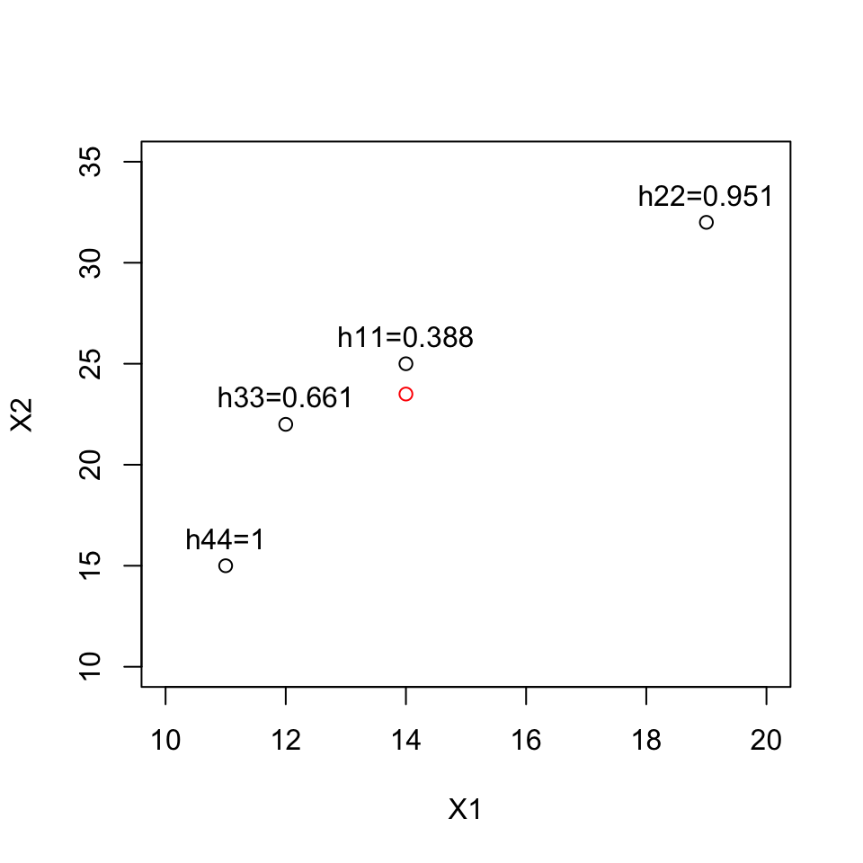

## Matriz “chapéu”

\(\hat{\mathbf{Y}}=\mathbf{H}\mathbf{Y}\), portanto cada \(\hat{Y}_i\) é uma combinação linear de todos os valores de \(Y\) e o peso de cada \(Y_i\) para o valor ajustado \(\hat{Y}_i\) depende de \(h_{ii}\).

Quanto maior \(h_{ii}\), maior o peso de \(Y_i\) em \(\hat{Y}_i\).

\(h_{ii}\) é uma função que depende apenas dos valores de \(X\), portanto, mede o papel dos valores de \(X\) na determinação da importância de cada \(Y_i\) no valor ajustado \(\hat{Y}_i\).

Quanto maior \(h_{ii}\), menor a variância de \(e_i\). Desta forma, quanto maior \(h_{ii}\), mais próximo \(\hat{Y}_i\) tenderá a estar de \(Y_i\).

## Ponto de alavanca

Um valor alavanca \(h_{ii}\) é considerado alto se é duas vezes maior que o valor de alavanca médio, denotado por \(\hat{h}\):

\[\bar{h}=\frac{\sum_{i=1}^nh_{ii}}{n}=\frac{p}{n}\]

Desta maneira, observações em que \(h_{ii}>2p/n\) são consideradas *outliers* com respeito aos valores de \(X\).

## Exemplo - Gordura corporal

```r
e <- resid(modelo1)
h <- hatvalues(modelo1)
t <- rstudent(modelo1)
round(data.frame("e"=e,"h"=h,"t"=t),3)
```

```
##         e     h      t
## 1  -1.683 0.201 -0.730
## 2   3.643 0.059  1.534
## 3  -3.176 0.372 -1.654
## 4  -3.158 0.111 -1.348
## 5   0.000 0.248  0.000
## 6  -0.361 0.129 -0.148
## 7   0.716 0.156  0.298
## 8   4.015 0.096  1.760
## 9   2.655 0.115  1.118
## 10 -2.475 0.110 -1.034
## 11  0.336 0.120  0.137
## 12  2.226 0.109  0.923
## 13 -3.947 0.178 -1.826
## 14  3.447 0.148  1.525
## 15  0.571 0.333  0.267
## 16  0.642 0.095  0.258
## 17 -0.851 0.106 -0.345
## 18 -0.783 0.197 -0.334
## 19 -2.857 0.067 -1.176
## 20  1.040 0.050  0.409
```

## Exemplo - Gordura corporal

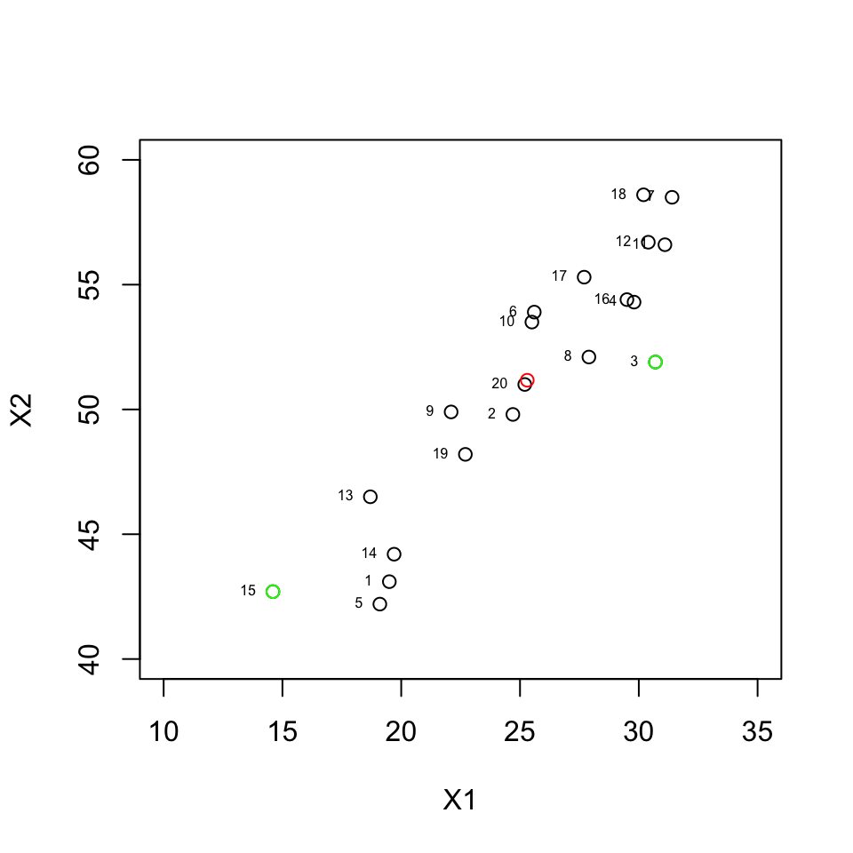

\(2p/n = 0.3\)

## Observações influentes

## Introdução

Após identificar casos *outliers* com respeito a \(Y\) e/ou \(X\), o próximo passo é verificar se esses casos são *influentes*.

Uma observação é considerada influente se sua exclusão causa grandes mudanças na regressão ajustada.

## *DFFITS* - Influência em um único valor ajustado

A influência que a \(i\)-ésima observação tem no valor ajustado \(\hat{Y}_i\) é medida por:

\[DFFITS_i=\frac{\hat{Y}_i-\hat{Y}_{i(i)}}{\sqrt{QME_{(i)}h_{ii}}}\]

O denominador é o desvio-padrão estimado de \(\hat{Y}_i\).

\[Var(\hat{\mathbf{Y}})=\mathbf{H}Var(\mathbf{Y})\mathbf{H}^T=\mathbf{H}(\sigma^2\mathbf{I})\mathbf{H}^T\]

Como \(\mathbf{H}=\mathbf{H}^T\) (simétrica) e \(\mathbf{H}\mathbf{H}=\mathbf{H}\) (idempotente), temos que:

\[Var(\hat{\mathbf{Y}})=\sigma^2\mathbf{H}\]

## *DFFITS* - Influência em um único valor ajustado

\[DFFITS_i=e_i\left[\frac{n-p-1}{SQE(1-h_{ii}-e_i^2)}\right]^{1/2}\left(\frac{h_{ii}}{1-h_{ii}} \right)^{1/2}=t_i\left(\frac{h_{ii}}{1-h_{ii}} \right)^{1/2}\]

Se uma observação é um *outlier* em \(X\) e tem alto valor de alavanca, \(DFFITS\) tenderá a ter um alto valor.

Para pequenos conjuntos de dados, se \(|DFFITS_i|>1\), a observação é considerada influente.

Para grandes conjuntos de dados, se \(|DFFITS_i|>2\sqrt{p/n}\), a observação é considerada influente.

## Exemplo - Gordura corporal

```r
format(dffits(modelo1),scientific = FALSE)
```

```
##                1                2                3                4
## "-0.36614723450" " 0.38381029454" "-1.27306744543" "-0.47634829704"
##                5                6                7                8
## "-0.00007292347" "-0.05668650028" " 0.12793708219" " 0.57452120091"
##                9               10               11               12
## " 0.40216488535" "-0.36387250695" " 0.05054582680" " 0.32333658364"
##               13               14               15               16
## "-0.85078122680" " 0.63551411143" " 0.18885207780" " 0.08376828665"
##               17               18               19               20
## "-0.11837349597" "-0.16552651714" "-0.31507065348" " 0.09399705521"
```

## *Cook’s Distance* - Influência em todos os valores ajustados

Medida para avaliar a influência de uma observação \(i\) no ajuste das \(n\) observações:

\[D_i=\frac{\sum_{j=1}^n(\hat{Y}_j-\hat{Y}_{j(i)})^2}{p QME}\]

Em forma matricial:

\[D_i=\frac{(\hat{\mathbf{Y}}-\hat{\mathbf{Y}}_{(i)})^T(\hat{\mathbf{Y}}-\hat{\mathbf{Y}}_{(i)})}{pQME}\]

## *Cook’s Distance* - Influência em todos os valores ajustados

\[D_i=\frac{e_i^2}{pQME}\left[\frac{h_{ii}}{(1-h_{ii})^2}\right]\]

Comparamos \(D_i\) com percentis de \(F(p,n-p)\): se for maior que o percentil 50, a \(i\)-ésima observação deve ser investigada como possível ponto influente.

## Exemplo - Gordura corporal

```r
format(cooks.distance(modelo1),scientific = FALSE)
```

```
##                   1                   2                   3                   4
## "0.045950548956025" "0.045481177306003" "0.490156678050177" "0.072161900262186"
##                   5                   6                   7                   8
## "0.000000001883399" "0.001136518329757" "0.005764939254433" "0.097938531802951"
##                   9                  10                  11                  12
## "0.053133515087085" "0.043957035227563" "0.000903798575500" "0.035154363872331"
##                  13                  14                  15                  16
## "0.212150240723778" "0.124892510084211" "0.012575299122032" "0.002474925197901"
##                  17                  18                  19                  20
## "0.004926142442252" "0.009636470211422" "0.032360064480030" "0.003096787039886"
```

## Exemplo - Gordura corporal

```r
caso3 <- cooks.distance(modelo1)[3]
p=length(coefficients(modelo1))
n=dim(dat)[1]
perc=pf(caso3,df1=p,df2=n-p)
```

Caso \(3\) tem o maior valor: \(D_3=0.49\). Este valor corresponde ao percentil 30.6 da distribuição \(F(p,n-p)\).

## \(DFBETAS\) - influência nos coeficientes da regressão

Medida de influência da \(i\)-ésima observação no coeficiente \(\hat{\beta}_k\):

\[DFBETAS_{k(i)}=\frac{\hat{\beta}_k-\hat{\beta}_{k(i)}}{\sqrt{QME_{(i)}c_{kk}}}\]

em que \(c_{kk}\) é o \(k\)-ésimo elemento da diagonal de \((\mathbf{X}^T\mathbf{X})^{-1}\).

Para pequenos conjuntos de dados, se \(|DFBETAS_{k(i)}|>1\), a observação é considerada influente.

Para grandes conjuntos de dados, se \(|DFBETAS_{k(i)}|>2/\sqrt{n}\), a observação é considerada influente.

## Exemplo - Gordura corporal

```r
format(dfbetas(modelo1),scientific = FALSE)
```

```
##    (Intercept)      X1               X2
## 1  "-0.30518208063" "-0.13148559192" " 0.23203185250"
## 2  " 0.17257315757" " 0.11502507830" "-0.14261289523"
## 3  "-0.84710125907" "-1.18252488189" " 1.06690317579"
## 4  "-0.10161195986" "-0.29351950126" " 0.19607192232"
## 5  "-0.00006372122" "-0.00003052747" " 0.00005023715"
## 6  " 0.03967715415" " 0.04008114113" "-0.04426759013"
## 7  "-0.07752748175" "-0.01561293306" " 0.05431633626"
## 8  " 0.26143123587" " 0.39112622713" "-0.33245331815"
## 9  "-0.15135207505" "-0.29465556652" " 0.24690908623"
## 10 " 0.23774917449" " 0.24460100708" "-0.26880860125"
## 11 "-0.00902088534" " 0.01705640110" "-0.00248451805"
## 12 "-0.13049333736" " 0.02245800361" " 0.06999608166"
## 13 " 0.11941465394" " 0.59242024965" "-0.38949127544"
## 14 " 0.45174371217" " 0.11317216394" "-0.29770422361"
## 15 "-0.00300427628" "-0.12475670942" " 0.06876928638"
## 16 " 0.00930846262" " 0.04311346974" "-0.02512498857"
## 17 " 0.07951207831" " 0.05504356655" "-0.07609007641"
## 18 " 0.13205215004" " 0.07532874247" "-0.11610031509"
## 19 "-0.12960322961" "-0.00407202961" " 0.06442930786"
## 20 " 0.01019045469" " 0.00229079680" "-0.00331414570"
```

## Exemplo - Gordura corporal

```r
influence.measures(modelo1)
```

```
## Influence measures of
##   lm(formula = Y ~ X1 + X2, data = dat) :
##
##       dfb.1_    dfb.X1    dfb.X2     dffit cov.r   cook.d    hat inf
## 1  -3.05e-01 -1.31e-01  2.32e-01 -3.66e-01 1.361 4.60e-02 0.2010
## 2   1.73e-01  1.15e-01 -1.43e-01  3.84e-01 0.844 4.55e-02 0.0589
## 3  -8.47e-01 -1.18e+00  1.07e+00 -1.27e+00 1.189 4.90e-01 0.3719   *
## 4  -1.02e-01 -2.94e-01  1.96e-01 -4.76e-01 0.977 7.22e-02 0.1109
## 5  -6.37e-05 -3.05e-05  5.02e-05 -7.29e-05 1.595 1.88e-09 0.2480   *
## 6   3.97e-02  4.01e-02 -4.43e-02 -5.67e-02 1.371 1.14e-03 0.1286
## 7  -7.75e-02 -1.56e-02  5.43e-02  1.28e-01 1.397 5.76e-03 0.1555
## 8   2.61e-01  3.91e-01 -3.32e-01  5.75e-01 0.780 9.79e-02 0.0963
## 9  -1.51e-01 -2.95e-01  2.47e-01  4.02e-01 1.081 5.31e-02 0.1146
## 10  2.38e-01  2.45e-01 -2.69e-01 -3.64e-01 1.110 4.40e-02 0.1102
## 11 -9.02e-03  1.71e-02 -2.48e-03  5.05e-02 1.359 9.04e-04 0.1203
## 12 -1.30e-01  2.25e-02  7.00e-02  3.23e-01 1.152 3.52e-02 0.1093
## 13  1.19e-01  5.92e-01 -3.89e-01 -8.51e-01 0.827 2.12e-01 0.1784
## 14  4.52e-01  1.13e-01 -2.98e-01  6.36e-01 0.937 1.25e-01 0.1480
## 15 -3.00e-03 -1.25e-01  6.88e-02  1.89e-01 1.775 1.26e-02 0.3332   *
## 16  9.31e-03  4.31e-02 -2.51e-02  8.38e-02 1.309 2.47e-03 0.0953
## 17  7.95e-02  5.50e-02 -7.61e-02 -1.18e-01 1.312 4.93e-03 0.1056
## 18  1.32e-01  7.53e-02 -1.16e-01 -1.66e-01 1.462 9.64e-03 0.1968
## 19 -1.30e-01 -4.07e-03  6.44e-02 -3.15e-01 1.002 3.24e-02 0.0670
## 20  1.02e-02  2.29e-03 -3.31e-03  9.40e-02 1.224 3.10e-03 0.0501
```

## Inflação da variância

## Introdução

Problemas quando variáveis preditoras apresentam correlação alta entre si:

- Incluir ou excluir uma variável preditora altera os coeficientes da regressão.
- Os erros padrão dos coeficientes estimados ficam muito grandes.

> A presença de multicolinearidade pode ser investigada através dos seguintes diagnósticos informais:
- Grandes mudanças nas estimativas dos parâmetros de regressão quando uma variável é incluída ou exclluída do modelo.
- Estimativa dos parâmetros de regressão com sinal oposto do que seria esperado, segundo informações/conhecimento prévio.

## Exemplo - Gordura corporal

|  | Estimativa | Erro-Padrão | t | valor de p |
| --- | --- | --- | --- | --- |
| (Intercept) | -19.1742456 | 8.3606407 | -2.2933943 | 0.0348433 |
| X1 | 0.2223526 | 0.3034389 | 0.7327755 | 0.4736790 |
| X2 | 0.6594218 | 0.2911873 | 2.2645969 | 0.0368987 |

## Exemplo - Gordura corporal

|  | Estimativa | Erro-Padrão | t | valor de p |
| --- | --- | --- | --- | --- |
| (Intercept) | 117.084695 | 99.782403 | 1.173400 | 0.2578078 |
| X1 | 4.334092 | 3.015511 | 1.437266 | 0.1699111 |
| X2 | -2.856848 | 2.582015 | -1.106441 | 0.2848944 |
| X3 | -2.186060 | 1.595499 | -1.370142 | 0.1895628 |

## \(VIF\) - fator de inflação da variância

Lembrando:

\[Var(\hat{\boldsymbol{\beta}})=\sigma^2(\mathbf{X}^T\mathbf{X})^{-1}\]

> Para medir o impacto da multicolinearidade, é mais útil trabalhar com as variáveis com transformação de correlação, vistas anteriormente.

\[Var(\hat{\boldsymbol{\beta}^*})=(\sigma^*)^2\mathbf{r}_{XX}^{-1}\]

> Definindo \(VIF_k\) (fator de inflação da variância para \(\hat{\beta_k^*}\)) como o \(k\)-ésimo elemento de \(\mathbf{r}_{XX}^{-1}\), temos:

\[Var(\hat{\beta_k^*})=(\sigma^*)^2VIF_k\]

## \(VIF\) - fator de inflação da variância

Pode-se reescrever:

\[VIF_k=(1-R_k^2)^{-1}\]

em que \(R_k^2\) é o coeficiente de determinação da regressão de \(X_k\) nas demais variáveis preditoras.

Quando \(R_k^2=0\), \(VIF_k=1\), caso contrário, \(VIF_k>1\).

## Exemplo - Gordura corporal

Variáveis escala original

```r
modelo2 <- lm(Y ~ X1 + X2 + X3,data=dat)
kable(summary(modelo2)$coef,col.names = c("Estimativa","Erro-Padrão","t","valor de p"))
```

|  | Estimativa | Erro-Padrão | t | valor de p |
| --- | --- | --- | --- | --- |
| (Intercept) | 117.084695 | 99.782403 | 1.173400 | 0.2578078 |
| X1 | 4.334092 | 3.015511 | 1.437266 | 0.1699111 |
| X2 | -2.856848 | 2.582015 | -1.106441 | 0.2848944 |
| X3 | -2.186060 | 1.595499 | -1.370142 | 0.1895628 |

## Exemplo - Gordura corporal

Variáveis padronizadas

|  | Estimativa | Erro-Padrão | t | valor de p |
| --- | --- | --- | --- | --- |
| X1 | 4.263705 | 2.877965 | 1.481500 | 0.1567712 |
| X2 | -2.928701 | 2.567924 | -1.140493 | 0.2698942 |
| X3 | -1.561417 | 1.105576 | -1.412310 | 0.1759032 |

## Exemplo - Gordura corporal

```r
library(car)
vif(modelo2)
```

```
##       X1       X2       X3
## 708.8429 564.3434 104.6060
```

## Agradecimento

- Slides criados por Samara F Kiihl / IMECC / UNICAMP

## Leitura

- Applied Linear Statistical Models: Capítulo 10.
- Faraway - [Linear Models with R](http://www.maths.bath.ac.uk/~jjf23/LMR/): Capítulo 6, Seção 7.3
- Draper & Smith - [Applied Regression Analysis](http://onlinelibrary.wiley.com/book/10.1002/9781118625590): Capítulo 8.
- Caffo - [Regression Models for Data Science in R](https://leanpub.com/regmods): Residuals, variation, diagnostics.

[figure not shown]

## Agradecimentos

- Samara F Kiihl
- Benilton S Carvalho
- Rafael P Maia